Skip to main content

# Data summary of my four flux towers

Author

Lilly

Published

Invalid Date

# Data Summary Report

## Section 1 - Overview

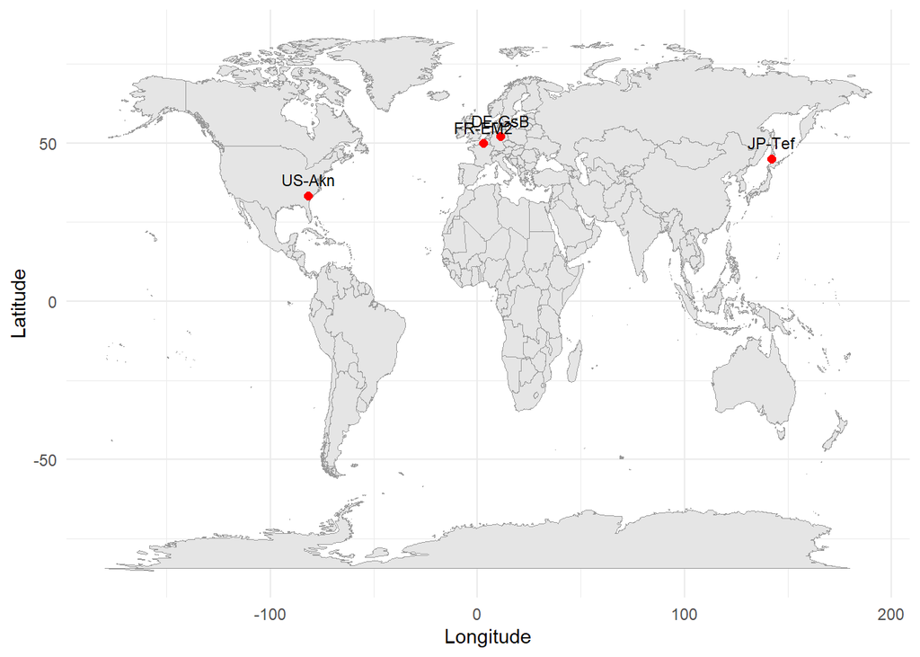

```r
#libraries
library (ggplot2)
library(tidyverse)
library(knitr)
library(here)

#data
sites <- c("JP-Tef", "US-Akn", "DE-GsB", "FR-EM2")
snapshots <- read.csv(here("data", "snapshots", "fluxnet_shuttle_snapshot_20261113T105848.csv"))

overview <- snapshots |>
    filter(site_id %in% sites) |>
    select(site_id, site_name, location_lat, location_long, igbp, first_year, last_year, data_hub, network, product_citation)

# map
lat <- overview$location_lat
long <- overview$location_long

world <- map_data("world")
ggplot() +
  geom_polygon(data = world, aes(x = long, y = lat, group = group),
               fill = "grey90", colour = "grey60", linewidth = 0.2) +
  geom_point(data = overview, aes(x = long, y = lat), colour = "red", size = 2) +
  geom_text(data = overview, aes(x = long, y = lat, label = site_id),
            size = 3, vjust = -0.8) +
  #coord_quickmap(xlim = c(-10, 30), ylim = c(35, 60)) +   # zoom to Europe
  theme_minimal() +
  labs(x = "Longitude", y = "Latitude")
```

## Section 2 - Data coverage

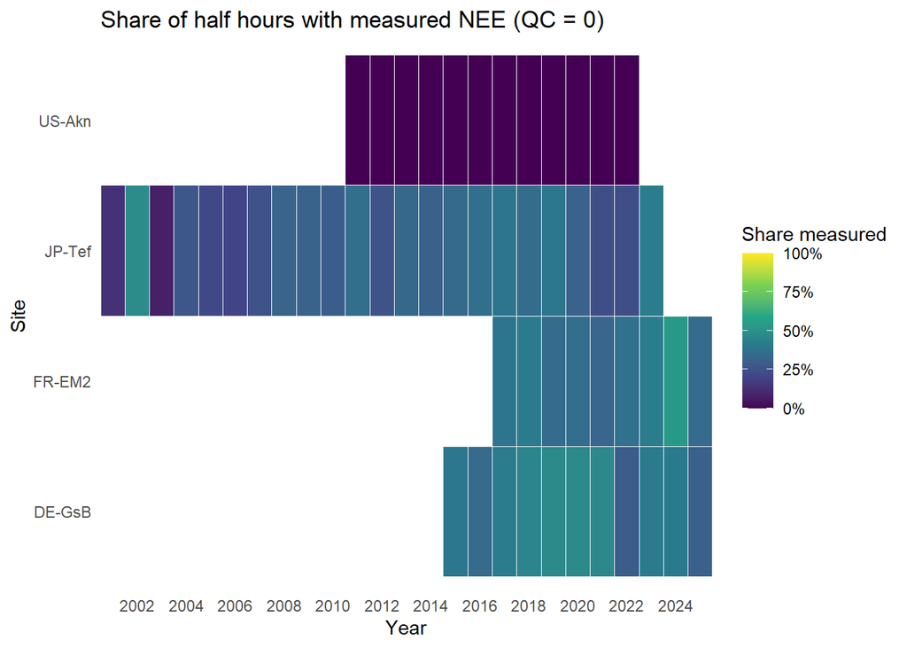

```r
# heatmap
data <- read_csv(here("data", "complete_data.csv"),
                 col_types = cols(TIMESTAMP_START = "c", TIMESTAMP_END = "c",
                                  site = "c", time = "-", .default = "d")) |>
  mutate(time = as.POSIXct(TIMESTAMP_START, format = "%Y%m%d%H%M", tz = "UTC"))

nee_share <- data|>
  mutate(year = year(time)) |>
  group_by(site, year) |>
  summarise(share_measured = mean(NEE_VUT_REF_QC %in% 0),   # TRUE = 1, FALSE = 0
            n_halfhours    = n(),
            .groups = "drop")

ggplot(nee_share, aes(x = year, y = site, fill = share_measured)) +
  geom_tile(colour = "white", linewidth = 0.3) +
  scale_fill_viridis_c(name = "Share measured",
                       labels = scales::percent,
                       limits = c(0, 1)) +
  scale_x_continuous(breaks = scales::breaks_width(2), expand = c(0, 0)) +
  labs(x = "Year", y = "Site",
       title = "Share of half hours with measured NEE (QC = 0)") +
  theme_minimal() +
  theme(panel.grid = element_blank())
```

Best coverage site: by JP-Tef, since it is the longest one (2001-2023) Years are best covered from 2017-2022

## Section 3 - Summary statistics

```r
vars <- c("TA_F", "SW_IN_F", "VPD_F", "P_F", "NEE_VUT_REF",
          "GPP_NT_VUT_REF", "RECO_NT_VUT_REF", "H_F_MDS", "LE_F_MDS")

units <- c(TA_F            = "°C",
           SW_IN_F         = "W m⁻²",
           VPD_F           = "hPa",
           P_F             = "mm; Mean = annual sum in mm yr⁻¹",
           NEE_VUT_REF     = "µmol CO₂ m⁻² s⁻¹",
           GPP_NT_VUT_REF  = "µmol CO₂ m⁻² s⁻¹",
           RECO_NT_VUT_REF = "µmol CO₂ m⁻² s⁻¹",
           H_F_MDS         = "W m⁻²",
           LE_F_MDS        = "W m⁻²")

# 1. Mean, min, max and % missing per site and variable
summary_long <- data |>
  pivot_longer(all_of(vars), names_to = "variable", values_to = "value") |>
  group_by(site, variable) |>
  summarise(all_na        = all(is.na(value)),
            Mean          = if (all_na) NA_real_ else mean(value, na.rm = TRUE),
            Min           = if (all_na) NA_real_ else min(value, na.rm = TRUE),
            Max           = if (all_na) NA_real_ else max(value, na.rm = TRUE),
            `Missing (%)` = 100 * mean(is.na(value)),
            .groups = "drop") |>
  select(-all_na)

# 2. Precipitation: mean of the annual sums
p_annual <- data |>
  group_by(site, year = year(time)) |>
  summarise(p_sum = sum(P_F, na.rm = TRUE), .groups = "drop") |>
  group_by(site) |>
  summarise(p_mean_annual = mean(p_sum))

summary_long <- summary_long |>
  left_join(p_annual, by = "site") |>
  mutate(Mean = if_else(variable == "P_F", p_mean_annual, Mean)) |>
  select(-p_mean_annual)

# 3. Reshape: statistics as rows, variables (with units) as columns
headers <- paste0(vars, " (", units[vars], ")")

site_tables <- summary_long |>
  mutate(variable = factor(paste0(variable, " (", units[variable], ")"), levels = headers)) |>
  pivot_longer(c(Mean, Min, Max, `Missing (%)`), names_to = "Statistic") |>
  mutate(Statistic = factor(Statistic, levels = c("Mean", "Min", "Max", "Missing (%)"))) |>
  pivot_wider(names_from = variable, values_from = value, names_sort = TRUE) |>
  arrange(site, Statistic)

# 4. one table per site
for (s in unique(site_tables$site)) {
  assign(paste0("summary_", gsub("-", "_", s)),
         site_tables |> filter(site == s) |> select(-site))
}

print(summary_DE_GsB)
```

```
# A tibble: 4 × 10
  Statistic   `TA_F (°C)` `SW_IN_F (W m⁻²)` `VPD_F (hPa)` P_F (mm; Mean = annu…¹
  <fct>             <dbl>             <dbl>         <dbl>                  <dbl>
1 Mean               10.2              132.          3.99                  498.
2 Min               -24.2                0           0                       0
3 Max                37.8             1062.         54.2                    30.9
4 Missing (%)         0                  0           0                       0
# ℹ abbreviated name: ¹`P_F (mm; Mean = annual sum in mm yr⁻¹)`
# ℹ 5 more variables: `NEE_VUT_REF (µmol CO₂ m⁻² s⁻¹)` <dbl>,
#   `GPP_NT_VUT_REF (µmol CO₂ m⁻² s⁻¹)` <dbl>,
#   `RECO_NT_VUT_REF (µmol CO₂ m⁻² s⁻¹)` <dbl>, `H_F_MDS (W m⁻²)` <dbl>,
#   `LE_F_MDS (W m⁻²)` <dbl>
```

```r
print(summary_FR_EM2)
```

```
# A tibble: 4 × 10
  Statistic   `TA_F (°C)` `SW_IN_F (W m⁻²)` `VPD_F (hPa)` P_F (mm; Mean = annu…¹
  <fct>             <dbl>             <dbl>         <dbl>                  <dbl>
1 Mean              11.3               138.          3.46                  689.
2 Min               -9.33                0           0                       0
3 Max               41.2              1038          64.8                    24.2
4 Missing (%)        0                   0           0                       0
# ℹ abbreviated name: ¹`P_F (mm; Mean = annual sum in mm yr⁻¹)`
# ℹ 5 more variables: `NEE_VUT_REF (µmol CO₂ m⁻² s⁻¹)` <dbl>,
#   `GPP_NT_VUT_REF (µmol CO₂ m⁻² s⁻¹)` <dbl>,
#   `RECO_NT_VUT_REF (µmol CO₂ m⁻² s⁻¹)` <dbl>, `H_F_MDS (W m⁻²)` <dbl>,
#   `LE_F_MDS (W m⁻²)` <dbl>
```

```r
print(summary_JP_Tef)
```

```
# A tibble: 4 × 10
  Statistic   `TA_F (°C)` `SW_IN_F (W m⁻²)` `VPD_F (hPa)` P_F (mm; Mean = annu…¹
  <fct>             <dbl>             <dbl>         <dbl>                  <dbl>
1 Mean               5.97              124.          2.32                  920.
2 Min              -22.1                 0           0                       0
3 Max               33.1              1108          31.0                    44.1
4 Missing (%)        0                   0           0                       0
# ℹ abbreviated name: ¹`P_F (mm; Mean = annual sum in mm yr⁻¹)`
# ℹ 5 more variables: `NEE_VUT_REF (µmol CO₂ m⁻² s⁻¹)` <dbl>,
#   `GPP_NT_VUT_REF (µmol CO₂ m⁻² s⁻¹)` <dbl>,
#   `RECO_NT_VUT_REF (µmol CO₂ m⁻² s⁻¹)` <dbl>, `H_F_MDS (W m⁻²)` <dbl>,
#   `LE_F_MDS (W m⁻²)` <dbl>
```

```r
print(summary_US_Akn)
```

```
# A tibble: 4 × 10
  Statistic   `TA_F (°C)` `SW_IN_F (W m⁻²)` `VPD_F (hPa)` P_F (mm; Mean = annu…¹
  <fct>             <dbl>             <dbl>         <dbl>                  <dbl>
1 Mean               17.0              186.          4.73                  46.5
2 Min               -10.5                0           0                      0
3 Max                38.0             1145.         40.4                    1.82
4 Missing (%)         0                  0           0                      0
# ℹ abbreviated name: ¹`P_F (mm; Mean = annual sum in mm yr⁻¹)`
# ℹ 5 more variables: `NEE_VUT_REF (µmol CO₂ m⁻² s⁻¹)` <dbl>,
#   `GPP_NT_VUT_REF (µmol CO₂ m⁻² s⁻¹)` <dbl>,
#   `RECO_NT_VUT_REF (µmol CO₂ m⁻² s⁻¹)` <dbl>, `H_F_MDS (W m⁻²)` <dbl>,
#   `LE_F_MDS (W m⁻²)` <dbl>
```

## Section 4 - Time Series

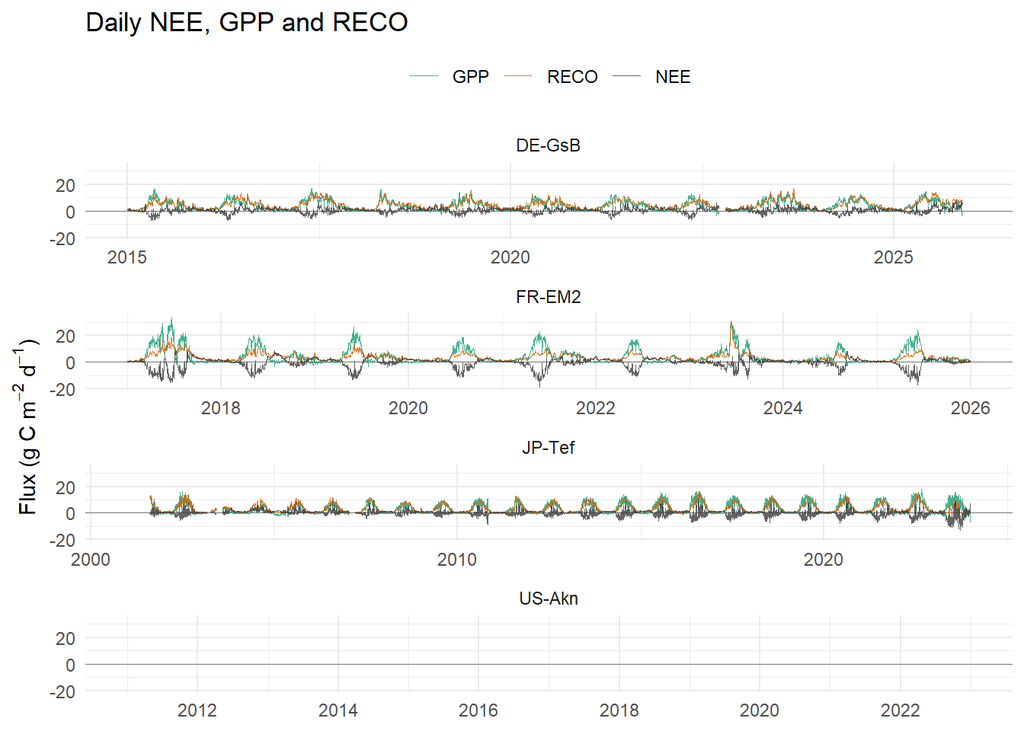

```r
flux_vars <- c("NEE_VUT_REF", "GPP_NT_VUT_REF", "RECO_NT_VUT_REF")
conv <- 1.0378   # µmol CO2 m-2 s-1  ->  g C m-2 d-1

# 1. Aggregate half-hourly data to daily values
daily <- data |>
  mutate(date = as_date(time)) |>
  group_by(site, date) |>
  summarise(across(all_of(flux_vars),
                   list(val = \(x) mean(x, na.rm = TRUE) * conv,
                        n   = \(x) sum(!is.na(x)))),
            .groups = "drop") |>
  # only keep days that have all 48 half hours
  mutate(NEE  = if_else(NEE_VUT_REF_n     == 48, NEE_VUT_REF_val,     NA),
         GPP  = if_else(GPP_NT_VUT_REF_n  == 48, GPP_NT_VUT_REF_val,  NA),
         RECO = if_else(RECO_NT_VUT_REF_n == 48, RECO_NT_VUT_REF_val, NA)) |>
  select(site, date, NEE, GPP, RECO)

# 2. Plot: one panel per site
daily |>
  pivot_longer(c(NEE, GPP, RECO), names_to = "flux", values_to = "value") |>
  mutate(flux = factor(flux, levels = c("GPP", "RECO", "NEE"))) |>
  ggplot(aes(x = date, y = value, colour = flux)) +
  geom_hline(yintercept = 0, colour = "grey50", linewidth = 0.3) +
  geom_line(linewidth = 0.25, alpha = 0.8) +
  facet_wrap(~ site, ncol = 1, scales = "free_x") +
  scale_colour_manual(values = c(GPP = "#1b9e77", RECO = "#d95f02", NEE = "#3d3d3d")) +
  labs(x = NULL, y = expression("Flux (g C m"^-2*" d"^-1*")"), colour = NULL,
       title = "Daily NEE, GPP and RECO") +
  theme_minimal() +
  theme(legend.position = "top")
```

```r
# 3. Check against the FLUXMET_DD file for one site
check_site <- "DE-GsB"

zip_file <- list.files(here("data", "raw"),
                       pattern = paste0(check_site, ".*\\.zip$"),   # only this site's zip
                       full.names = TRUE)
dd_name  <- grep("FLUXMET_DD", unzip(zip_file, list = TRUE)$Name, value = TRUE)
unzip(zip_file, files = dd_name, exdir = here("data", "raw", "unzipped"))

dd <- read_csv(here("data", "raw", "unzipped", dd_name),
               na = "-9999",
               col_select = c(TIMESTAMP, all_of(flux_vars)),
               col_types = cols(TIMESTAMP = "c", .default = "d")) |>
  mutate(date = as_date(TIMESTAMP, format = "%Y%m%d"))

comparison <- daily |>
  filter(site == check_site) |>
  inner_join(dd, by = "date")

# Differences (should be close to 0)
comparison |>
  summarise(NEE_max_diff  = max(abs(NEE  - NEE_VUT_REF),     na.rm = TRUE),
            GPP_max_diff  = max(abs(GPP  - GPP_NT_VUT_REF),  na.rm = TRUE),
            RECO_max_diff = max(abs(RECO - RECO_NT_VUT_REF), na.rm = TRUE),
            NEE_r         = cor(NEE, NEE_VUT_REF, use = "complete.obs"))
```

```
# A tibble: 1 × 4
  NEE_max_diff GPP_max_diff RECO_max_diff NEE_r
         <dbl>        <dbl>         <dbl> <dbl>
1     0.000623         4.20       0.00129 1.000
```

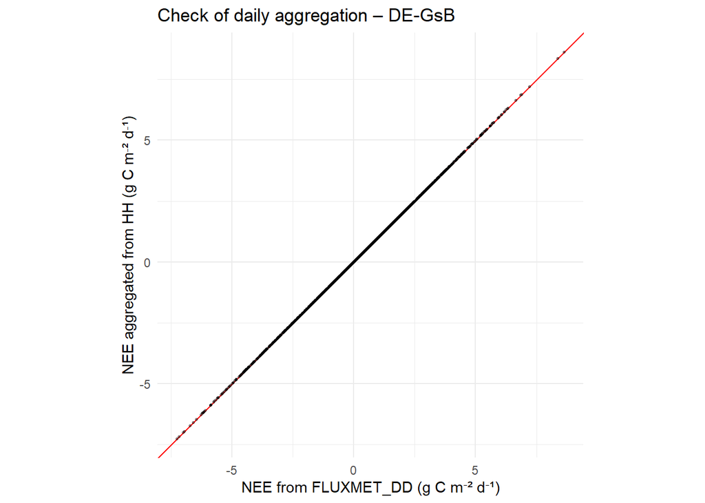

```r
# Visual check: points should lie on the 1:1 line
ggplot(comparison, aes(x = NEE_VUT_REF, y = NEE)) +
  geom_abline(slope = 1, intercept = 0, colour = "red") +
  geom_point(size = 0.5, alpha = 0.4) +
  coord_equal() +
  labs(x = "NEE from FLUXMET_DD (g C m⁻² d⁻¹)",
       y = "NEE aggregated from HH (g C m⁻² d⁻¹)",
       title = paste("Check of daily aggregation –", check_site)) +
  theme_minimal()
```

## Section 5 - Diurnal Cycle

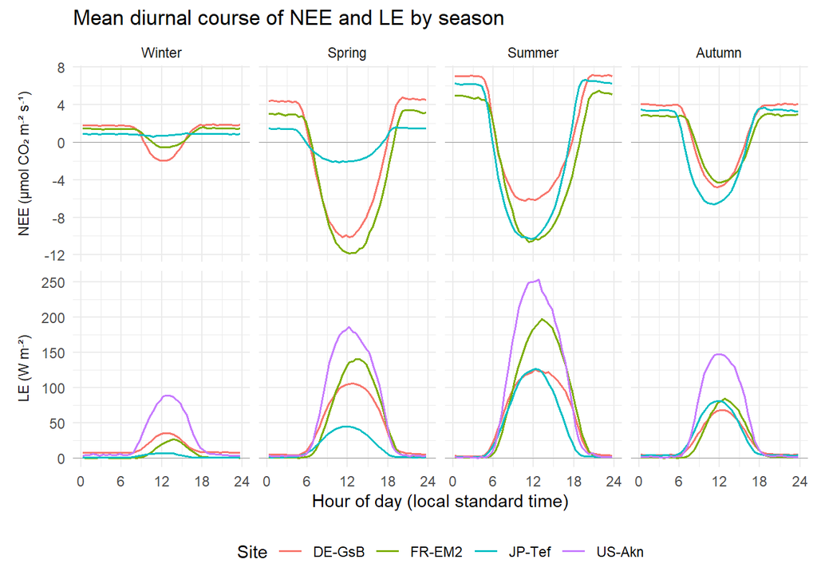

```r
# Latitude per site (adjust column names to your snapshots table)
site_info <- snapshots |>
  distinct(site = site_id, lat = location_lat)

season_levels <- c("Winter", "Spring", "Summer", "Autumn")

diurnal <- data |>
  left_join(site_info, by = "site") |>
  mutate(
    month = month(time),
    # meteorological seasons for the northern hemisphere
    season_nh = case_when(month %in% c(12, 1, 2) ~ "Winter",
                          month %in% 3:5         ~ "Spring",
                          month %in% 6:8         ~ "Summer",
                          TRUE                   ~ "Autumn"),
    # southern hemisphere: shift by half a year
    season = if_else(lat >= 0, season_nh,
                     recode(season_nh, Winter = "Summer", Summer = "Winter",
                                       Spring = "Autumn", Autumn = "Spring")),
    season = factor(season, levels = season_levels),
    # hour of day, centred on the half hour (00:00–00:30 -> 0.25)
    hour = hour(time) + minute(time) / 60 + 0.25
  ) |>
  group_by(site, season, hour) |>
  summarise(NEE = mean(NEE_VUT_REF, na.rm = TRUE),
            LE  = mean(LE_F_MDS,    na.rm = TRUE),
            .groups = "drop") |>
  pivot_longer(c(NEE, LE), names_to = "variable", values_to = "value") |>
  mutate(variable = factor(variable, levels = c("NEE", "LE"),
                           labels = c("NEE (µmol CO₂ m⁻² s⁻¹)", "LE (W m⁻²)")))

# Safety check: every site needs a latitude
stopifnot(!anyNA(site_info$lat[site_info$site %in% unique(data$site)]))

ggplot(diurnal, aes(x = hour, y = value, colour = site)) +
  geom_hline(yintercept = 0, colour = "grey60", linewidth = 0.3) +
  geom_line(linewidth = 0.6) +
  facet_grid(variable ~ season, scales = "free_y", switch = "y") +
  scale_x_continuous(breaks = seq(0, 24, 6), limits = c(0, 24)) +
  labs(x = "Hour of day (local standard time)", y = NULL, colour = "Site",
       title = "Mean diurnal course of NEE and LE by season") +
  theme_minimal() +
  theme(strip.placement = "outside", legend.position = "bottom")
```

### Seasonal Shift

For sites in the southern hemisphere (latitude < 0°), the seasons are shifted by six months: December–February is summer, March–May is autumn, June–August is winter and September–November is spring.

## Sectio 6 - Reading data

```r
data |>
  group_by(site) |>
  summarise(NETRAD_avail = mean(!is.na(NETRAD)),
            G_avail      = mean(!is.na(G_F_MDS)),
            .groups = "drop")
```

```
# A tibble: 4 × 3
  site   NETRAD_avail G_avail
  <chr>         <dbl>   <dbl>
1 DE-GsB        0       0.923
2 FR-EM2        0.664   0.785
3 JP-Tef        0.608   0.976
4 US-Akn        0       0
```

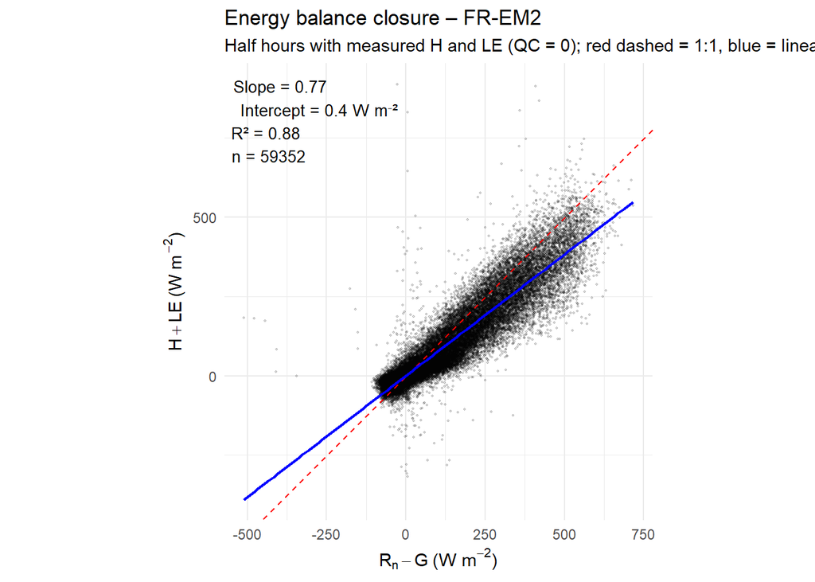

```r
eb_site <- "FR-EM2"   #site with NETRAD and G

eb <- data |>
  filter(site == eb_site,
         H_F_MDS_QC == 0, LE_F_MDS_QC == 0) |>          # H and LE measured
  mutate(turbulent = H_F_MDS + LE_F_MDS,
         available = NETRAD - G_F_MDS) |>
  filter(!is.na(turbulent), !is.na(available))

# Linear fit: turbulent fluxes ~ available energy
fit   <- lm(turbulent ~ available, data = eb)
slope <- coef(fit)[["available"]]
icpt  <- coef(fit)[[1]]
r2    <- summary(fit)$r.squared

label <- sprintf("Slope = %.2f\nIntercept = %.1f W m⁻²\nR² = %.2f\nn = %d",
                 slope, icpt, r2, nrow(eb))

ggplot(eb, aes(x = available, y = turbulent)) +
  geom_point(size = 0.4, alpha = 0.15) +
  geom_abline(slope = 1, intercept = 0, colour = "red", linetype = "dashed") +
  geom_smooth(method = "lm", formula = y ~ x, colour = "blue", se = FALSE, linewidth = 0.8) +
  annotate("text", x = -Inf, y = Inf, label = label, hjust = -0.1, vjust = 1.2, size = 3.5) +
  coord_equal() +
  labs(x = expression(R[n] - G ~ "(W m"^-2*")"),
       y = expression(H + LE ~ "(W m"^-2*")"),
       title = paste("Energy balance closure –", eb_site),
       subtitle = "Half hours with measured H and LE (QC = 0); red dashed = 1:1, blue = linear fit") +
  theme_minimal()
```

```r
# how much is gap filled?
qc_vars <- c("NEE_VUT_REF_QC", "H_F_MDS_QC", "LE_F_MDS_QC")

gapfill_site <- data |>
  group_by(site) |>
  summarise(across(all_of(qc_vars),
                   \(qc) round(100 * mean(qc > 0, na.rm = TRUE), 1),
                   .names = "{sub('_QC', '', .col)} gap-filled (%)"),
            .groups = "drop")

gapfill_site
```

```
# A tibble: 4 × 4
  site   NEE_VUT_REF gap-filled …¹ H_F_MDS gap-filled (…² LE_F_MDS gap-filled …³
  <chr>                      <dbl>                  <dbl>                  <dbl>
1 DE-GsB                      58.8                   30.9                   43.4
2 FR-EM2                      60.9                   16.9                   20.5
3 JP-Tef                      68.6                   36.5                   53.9
4 US-Akn                     NaN                     18.2                   26.1
# ℹ abbreviated names: ¹`NEE_VUT_REF gap-filled (%)`,
#   ²`H_F_MDS gap-filled (%)`, ³`LE_F_MDS gap-filled (%)`
```

### Summary

The site in France takes up most carbon in spring and summer, while the site in Germany takes up more carbon in winter and the site in Japan in autumn. The site in France has the largest seasonal cycle. Nice to see the mean diurnal cycle and was supprised that there is so inconsistent data and so much gap-filled. The site in Japan is gap-filled

## Citation and Data

Hirata, R., Takagi, K. (2025). Fluxnet Archive Product from CC-LaG Teshio Experimental Forest, 2001–2023, FLUXNET, https://hdl.handle.net/11676/U36jKvGfGICHSJO01Sk4jEZT  
Monique Leclerc (2026), AmeriFlux FLUXNET-1F US-Akn Savannah River Site, Ver. v1.3_r1 (2011-2022), AmeriFlux AMP, (Dataset). https://doi.org/10.17190/AMF/2469442  
Leonard, J., Bornet, F., François, B., Grehan, E. (2026). Fluxnet Archive Product from Estrees-Mons A28, 2017–2025, FLUXNET, https://hdl.handle.net/11676/tqY53lt1dCh3HZXtN-rLGEp5  
Hildebrandt, A., Rebmann, C., Bastos Campos, F., Dejosez, S., Dienstbach, L., Hautmann, D., Schmidt, P., Wiesen, R. (2026). Fluxnet Archive Product from Grosses Bruch, 2015–2025, FLUXNET, https://hdl.handle.net/11676/NY1UuClNrkeU0UUXUUoECmLZ

FLUXNET data products (ONEFlux v1.3, 2026 release), downloaded with the FLUXNET Shuttle from AmeriFlux, the ICOS Carbon Portal and TERN. Licence: CC-BY-4.0. When using the data, cite each site’s data product (the `cite` field in `sites.json`), cite Pastorello et al. (2020), *Scientific Data* 7, 225, https://doi.org/10.1038/s41597-020-0534-3, and include the FLUXNET acknowledgement:

> FLUXNET data products were produced and harmonized by eddy covariance regional networks and data processing centers, including AmeriFlux, ChinaFlux, European Fluxes Database, ICOS, JapanFlux, KoFlux, OzFlux, SAEON, and TERN. These products also include a modified version of ERA5 hourly data provided by the Copernicus Climate Change Service.

Pastorello et al. (2020), Scientific Data 7, 225, https://doi.org/10.1038/s41597-020-0534-3